# Lab_3_Yoo

Bonus (+50 points)

B1. make another Moran plot, this time do so manually (use geom_point from ggplot). You must label each quadrant with HH, HL, LL, and LH, respectively. You should also use color and/or shape to denote whether an observation is statistically significant. Tip, you can find the data you want using the moran.plot function, but you’ll have to alter the function call and read some documentation.

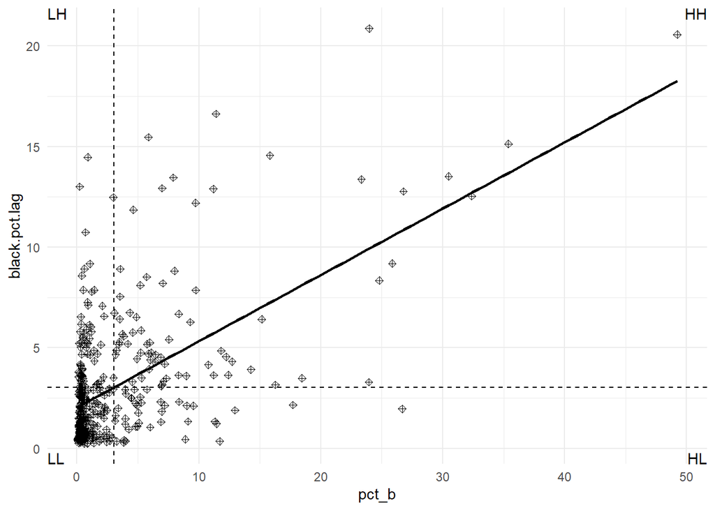

```r
annotations <- data.frame(
   xpos = c(-Inf,-Inf,Inf,Inf),
   ypos =  c(-Inf, Inf,-Inf,Inf),
   annotateText = c("LL","LH","HL","HH"),
   hjustvar = c(0,0,1,1) ,
   vjustvar = c(0,1.0,0,1))

ggplot(states.proj, aes(pct_b, black.pct.lag)) +
  geom_point(data=states.proj, aes(x=pct_b, y=black.pct.lag), shape=9) +
  geom_hline(yintercept=mean(black.pct.lag), lty=2) +
  geom_vline(xintercept=mean(states.proj$pct_b), lty=2) + theme_minimal() +
  geom_smooth(inherit.aes = TRUE, method="lm", se=F, col="black") +
  geom_text(data = annotations, aes(x=xpos,y=ypos,hjust=hjustvar,
                vjust=vjustvar,label=annotateText))
```

B2. plot a choropleth map of your dataset with a categorical color scheme, where the shading corresponds to the Moran plot (really, “LISA”) quadrants. Thus, your map will have four shades of color.

```r
local.m <- localmoran(states.proj$pct_b, states.w, zero.policy = T)
local.m
```

```
##                Ii          E.Ii       Var.Ii          Z.Ii Pr(z != E(Ii))
## 1   -0.1566531692 -3.858654e-04 2.590571e-02 -9.708908e-01   3.316027e-01
## 2    0.1820449133 -4.767041e-04 3.200140e-02  1.020304e+00   3.075841e-01
## 3   25.8961198192 -1.676711e-01 1.888632e+01  5.997412e+00   2.004869e-09
## 4    0.1029695970 -2.378159e-04 1.365318e-02  8.832712e-01   3.770898e-01
## 5    0.1993514454 -4.901361e-04 2.813195e-02  1.191478e+00   2.334661e-01
## 6    0.0717435231 -1.948998e-05 1.973250e-03  1.615510e+00   1.062004e-01
## 7    0.1435707415 -5.191442e-04 5.253414e-02  6.286554e-01   5.295747e-01
## 8    0.2382268672 -6.722885e-04 9.091967e-02  7.922928e-01   4.281900e-01
## 9    0.0608001803 -3.216551e-04 2.159623e-02  4.159177e-01   6.774702e-01
## 10   0.2191609373 -1.867790e-02 1.480914e+00  1.954420e-01   8.450470e-01
## 11  -0.0061195807 -2.207097e-04 1.482016e-02 -4.845543e-02   9.613533e-01
## 12  -0.0117237400 -5.174845e-04 5.236629e-02 -4.897051e-02   9.609428e-01
## 13   0.0669434851 -5.608170e-04 3.764478e-02  3.479197e-01   7.279005e-01
## 14  -0.0812284742 -3.136353e-04 2.533255e-02 -5.083803e-01   6.111866e-01
```

[output cut: 808 more lines]

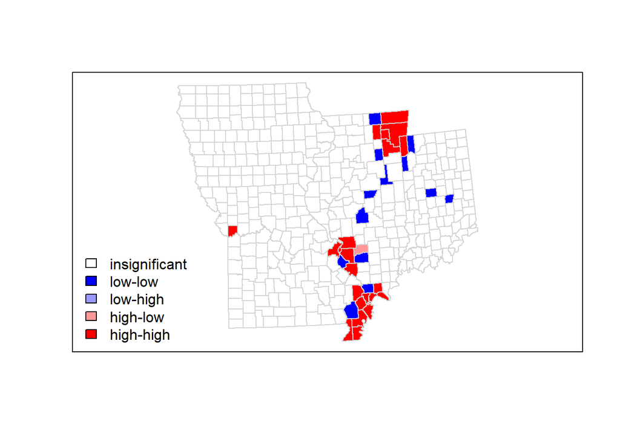

```r
quadrant <- vector(mode="numeric",length=nrow(local.m))

# centers the variable of interest around its mean
m.qualification <- states.proj$pct_b - mean(states.proj$pct_b)

# centers the local Moran's around the mean
m.local <- local.m[,1] - mean(local.m[,1])

# significance threshold
signif <- 0.1

# builds a data quadrant
quadrant[m.qualification >0 & m.local>0] <- 4
quadrant[m.qualification <0 & m.local<0] <- 1
quadrant[m.qualification <0 & m.local>0] <- 2
quadrant[m.qualification >0 & m.local<0] <- 3
quadrant[local.m[,5]>signif] <- 0

# plot in r
brks <- c(0,1,2,3,4)
colors <- c("white","blue",rgb(0,0,1,alpha=0.4),rgb(1,0,0,alpha=0.4),"red")
plot(states.proj$geometry, border="lightgray",col=colors[findInterval(quadrant,brks,all.inside=FALSE)])
box()
legend("bottomleft", legend = c("insignificant","low-low","low-high","high-low","high-high"),
       fill=colors,bty="n")
```